# Implementação do Programa de Diplomacia Cultural (PDC) pelo Ministério de Relações Exteriores do Brasil (MRE/Itamaraty) nos anos de 2013 e 2022

Setembro de 2024

## Objeto

Identificar, sistematizar e analisar dados relativos à implementação da política pública de política externa *‘Programa de Diplomacia Cultural’* (PDC), por parte da *Divisão de Operações de Difusão Cultural* (DODC), vinculada ao antigo *Departamento Cultural* (DC) [2013], e da *Divisão de Ações de Promoção da Cultura Brasileira*, do atual *Instituto Guimarães Rosa* (IGC) [2022] do Ministério de Relações Exteriores do Brasil (MRE/Itamaraty), como parte dos esfoços de diplomacia cultural mobilizados pela Política Externa Brasileira (PEB) nos exercícios anuais de 2013 e 2022.

## Objetivos

A interposição do método CDDAF sobre dados relacionados à implementação do PDC 2013 e PDC 2022 está orientada a responder às seguintes questões de pesquisa:

- Qual a quantidade (‘n’) de ações/eventos PDC implementados em 2013 e em 2022? Houve incremento quantitativo nesse expediente?
- Quais as destinações (continentes) receberam maior quantidade (‘n’) de ações/eventos PDC em 2013 e 2022?
- Quais os domínios culturais predominantes nas ações/eventos PDC em 2013 e 2022?
- Qual a proporcionalidade de indicadores indentitários de gênero e raça nos conteúdos artístico-culturais funcionalizados pelos PDC em 2013 e 2022?

## Contexto

- A evolução da literatura nacional no tema da diplomacia cultural brasileira têm carater indiscutivelmente histórico-descritivo, uma vez que mormente derivada de contribuições gestadas por intelectuais diplomatas.
- O tom oficioso geralmente encampado nestas contribuições é pouco elucidador sobre as práticas de Estado/governo em se tratando da implementação de políticas de diplomacia cultural do Brasil, i.e, quais o padrões de preferência em termos de destinação geográfica, conteúdos mobilizados, dentre outros marcadores de necessária reflexão na funcionalização deste expediente.
- Se faz urgente a mobilização de esforços científicos capazes de mensurar e verificar, a partir de metodologias baseadas em evidências, os resultados alcançados por meio da implementação de políticas públicas de política externa na arena setorial da diplomacia cultural brasileira.

## Métodos

- A pesquisa consistiu em esforços de coleta, codificação, tratamento e análise estatística de dados relativos a conteúdos, destinos e características identitárias marcantes nas ações/eventos de difusão internacional da cultura do Brasil, conforme facilitados através dos programas PDC 2013 e PDC 2022.
- O recorte temporal da pesquisa é arbitrário, mas pretende ilustrar, minimamente, a evolução diacrônica do expediente diplomática-cultural brasileiro a partir de dois exercícios anuais selecionados, quais sejam o de 2013 e 2022. Vale dizer que este intento faz parte de um desenho de pesquisa mais amplo, com recorte de 2013 a 2023. Aqui, buscou-se avaliar as relações entre algumas das variáveis de interesse no primeiro e no penúltimo ano do recorte temporal mais amplo.
- Emprega-se o modelo metodológico **Cutural Diplomacy Data Analisys Framework (CDDAF)** (Carrijo, 2016), que implica ser o marco científico em se tratando do estudo baseado em evidências sobre a diplomacia cultural, tendo como unidade de análise primordial os chamados projetos de diplomacia cultural tocados pelos Estados, neste caso, os próprios PDC 2013 e PDC 2022 facilitado pelas repartições competentes do MRE/Itamaraty.
- Adota-se do modelo CDDAF os seguintes variáveis de pesquisa quantitativa/qualitativa sobre a diplomacia cultural brasileira: (1) **número de projetos**; (2) **domínio cultural**, e; (3) **destinação geográfica (continente)** das ações empenhadas; além de mais um indicador qualitativo subjacente qual seja: (a) **paridade e proporcionalidade de gênero e raça** nas ações/eventos implementados.

## Métodos

- *Fontes* e *Coleta de Dados*: informações constantes nos chamados **Relatórios Anuais dos Programas PDC de 2013 e 2022**. Referidos documentos oficiais foram acessados via Lei de Acesso à Informação (LAI) n. 12527/11.
- *Codificação*: a codificação e extração de informações expressas nestes Relatórios Anuais foi estritamente orientada pelo método CDDAF (Carrijo, 2016), e obedeceu à uma moldura de códigos e categorias informados tanto pela literatura quanto pelo próprio expediente prático da diplomacia cultural brasileira. A fase de codificação foi conduzida com o suporte de CAQDAS, nomeadamente o *Atlas.TI*.
- *Tratamento*: foram construídas bases de dados distintas a partir de informações integrais oriundas dos mencionados **Relatórios Anuais dos PDC 2013 e 2022**. As variáveis quanti-quali (1) **número de projetos**; (2) **domínio cultural**, e; (3) **destinação geográfica (continente)** foram extraídas objetivamente, por meio da moldura de codificação e em face das evidências substantitvas documentadas na fonte em questão. O indicador qualitativo subjascente sobre a (a) **paridade e proporcionalidade de gênero e raça** foi atribuído a partir da reflexividade e posicionalidade do pesquisador diante dos dados expressos pelas fontes.
- *Análise Estatística*: construção de relações entre as variáveis quali-quanti de interesse, mensuração de estimativas intervalares e intervalos de confiança relacionados às quantidades e proporcionalidades alcançados pela rodagem do modelo, em face das amostras selecionadas. Foi empregado o software *R-Studio*, para tanto.

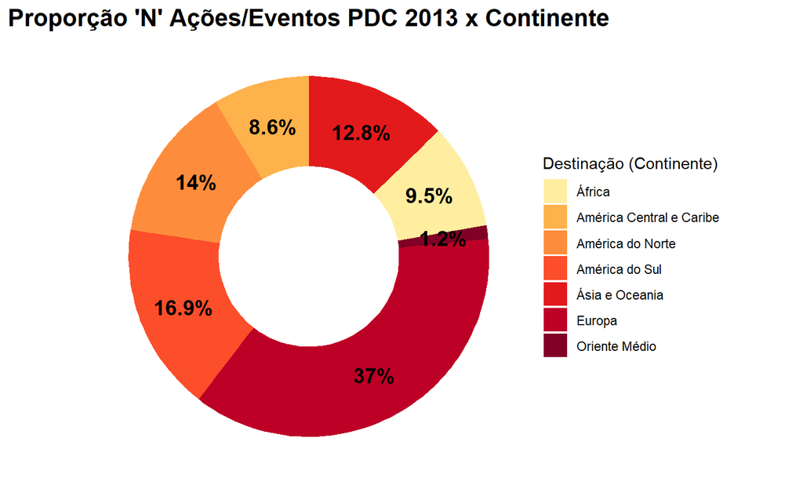

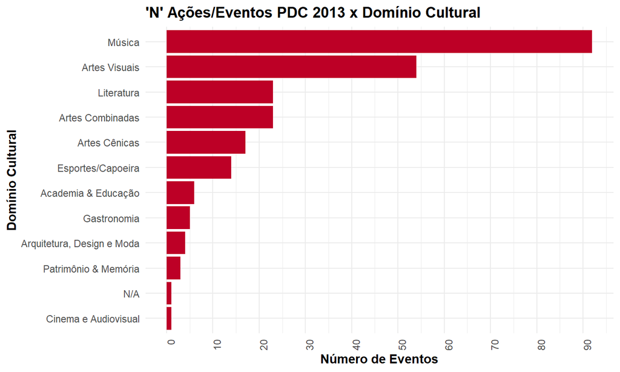

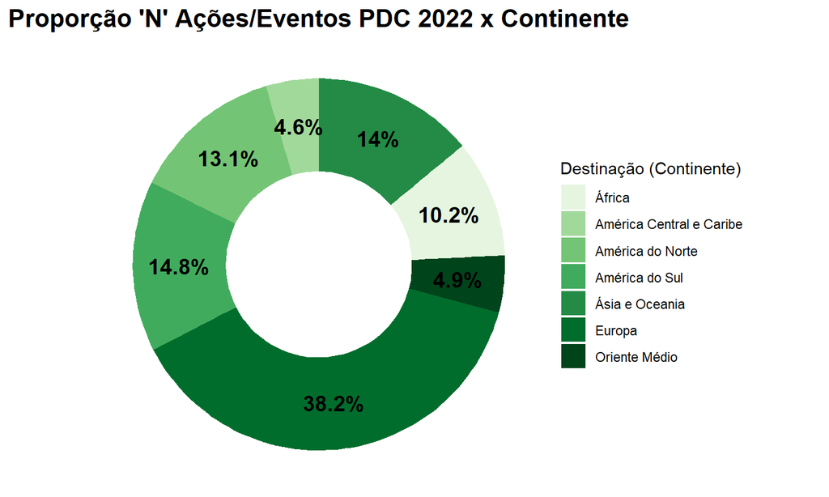

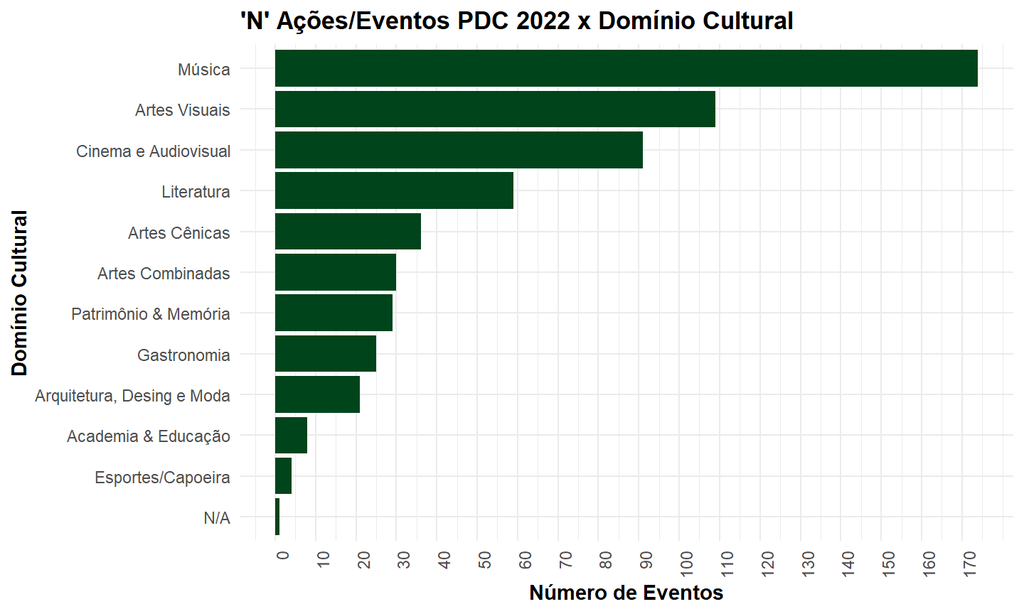

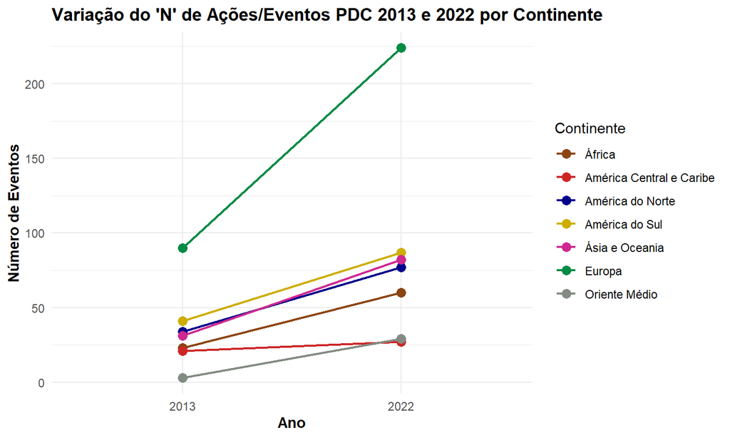

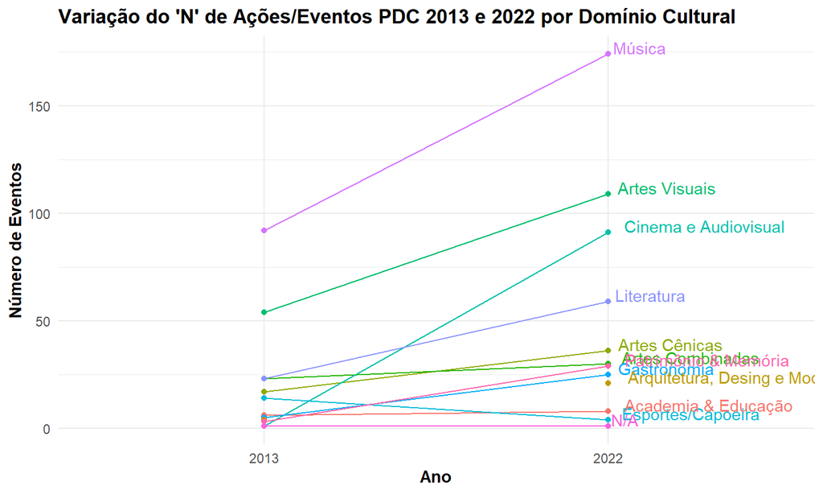

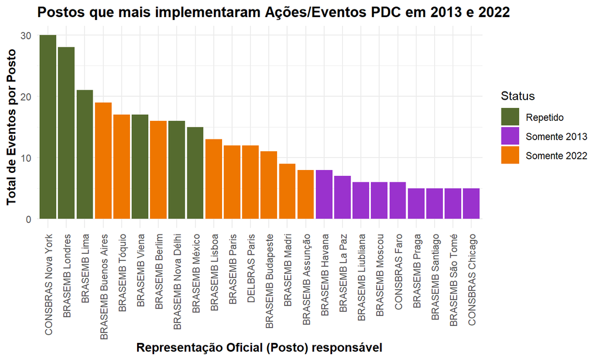

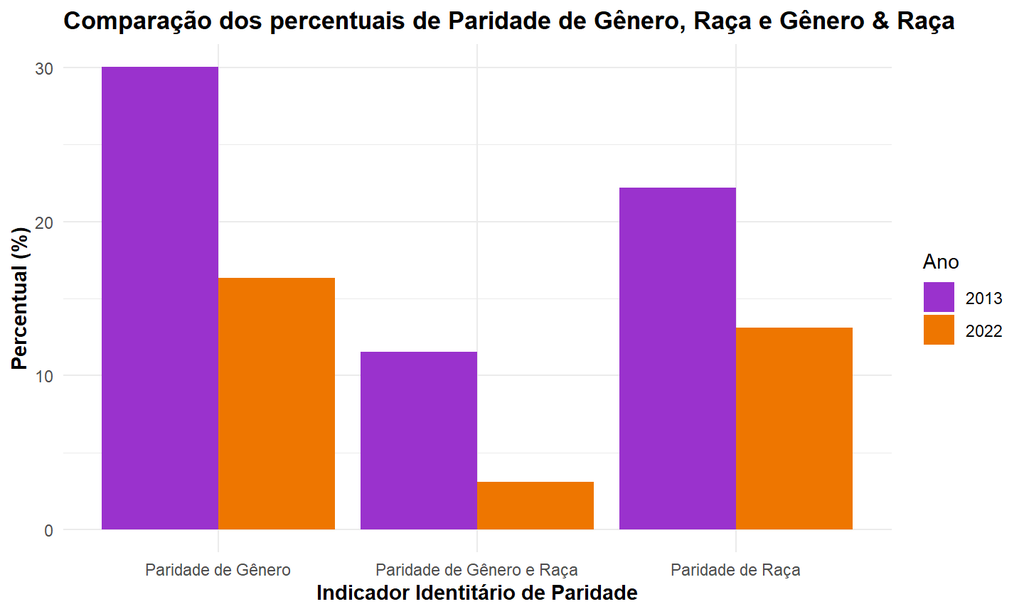